# SparkR Demo

# Machine Learning - *data exploration ctd*

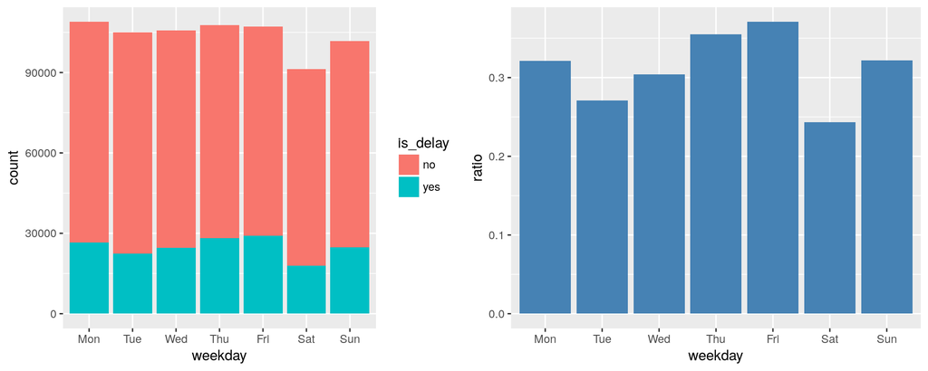

```r
# use as is
get_multiplot('weekday')
```

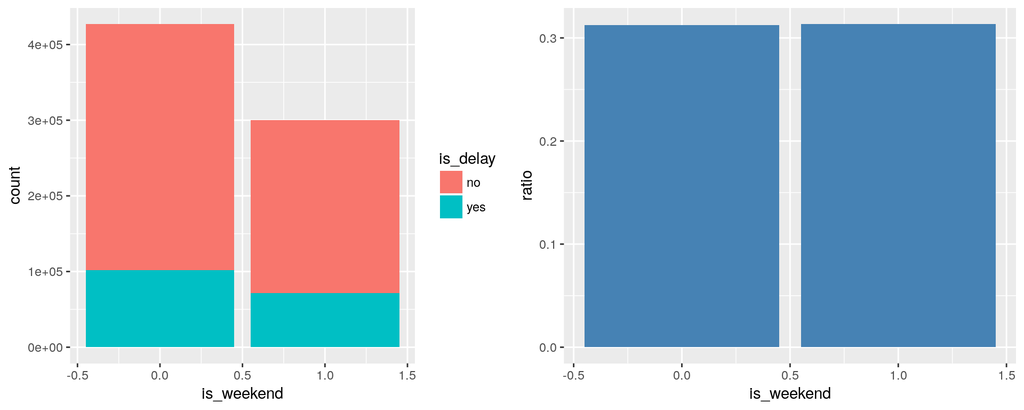

```r
# not using
get_multiplot('is_weekend')
```

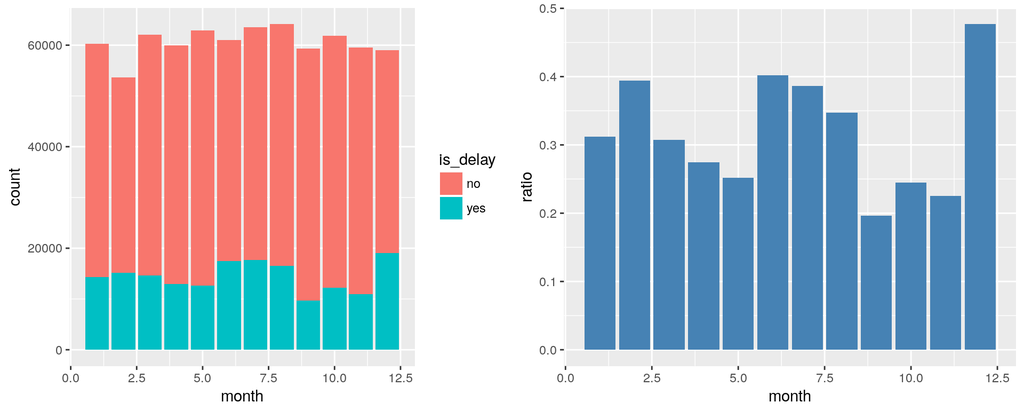

```r
# regrouping
# '1' if month is 12 or 1-3
# '2' if month is 6-8
# '3' if month is 4-5 or 9-11
get_multiplot('month')
```

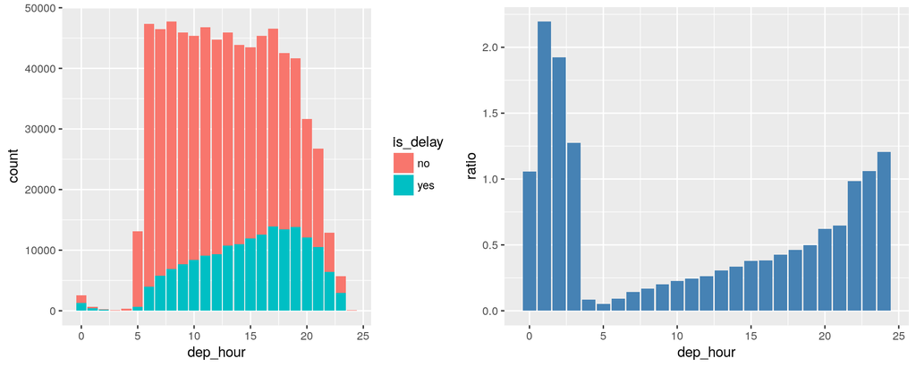

```r
# regrouping
# '1' if dep_hour is 4-12
# '2' if dep_hour is 13-19
# '3' if dep_hour is 0-3 or 20+
get_multiplot('dep_hour')
```

```r
## only use dep_delay
bind_rows(
  summarise_cont(dat_s, 'dep_delay'),
  summarise_cont(dat_s, 'distance'),
  summarise_cont(dat_s, 'air_time')
)
```

```
##         col is_delay        mean median  min  max
## 1 dep_delay       no  -0.4642659     -2 -168   85
## 2 dep_delay      yes  49.2538712     34  -49 1831
## 3  distance       no 713.9658008    557   21 4962
## 4  distance      yes 751.6156694    595   31 4962
## 5  air_time       no 100.7641820     83    0  641
## 6  air_time      yes 109.7099801     91    0  729
```

```r
## dep_delay is highly correlated with arr_delay
dat_s %>% dplyr::select(arr_delay, dep_delay) %>% cor()
```

```
##           arr_delay dep_delay
## arr_delay  1.000000  0.932244
## dep_delay  0.932244  1.000000
```

# Machine Learning - *feature generation*

```r
`%++%` <- function(a, b) paste(a, b)
month_c_expr <-
  "case when split(date, '/')[1] in ('6', '7', '8') then '2'" %++%
    "when split(date, '/')[1] in ('1', '2', '3', '12') then '1'" %++%
  "else '3' end"
weekday_expr <-
  "case date_format(to_date(date, 'yyyy/mm/dd'), 'E')" %++%
    "when 'Mon' then '1' when 'Tue' then '2'" %++%
    "when 'Wed' then '3' when 'Thu' then '4'" %++%
    "when 'Fri' then '5' when 'Sat' then '6'" %++%
  "else '7' end"
dep_hour_c_expr <-
  "case when cast(floor(dep_time/100) AS integer) <= 3 then '3'" %++%
    "when cast(floor(dep_time/100) AS integer) <= 12 then '1'" %++%
    "when cast(floor(dep_time/100) AS integer) <= 19 then '2'" %++%
  "else '3' end"

dat <- dat %>% dropna(cols = c('arr_delay', 'dep_delay')) %>%
  mutate(
    month_c = expr(month_c_expr),
    weekday = expr(weekday_expr),
    dep_hour_c = expr(dep_hour_c_expr),
    is_delay = ifelse(expr('arr_delay') > 15, 'yes', 'no')
) %>%
  filter(expr('cancelled == 0'))
```

```r
sel_cols <- c('is_delay', 'dep_delay', 'month_c', 'dep_hour_c', 'weekday')
dat %>% select(sel_cols) %>% head()

  is_delay dep_delay month_c dep_hour_c weekday
1       no         7       1          1       1
2       no        13       1          2       1
3      yes        36       1          3       1
4      yes        30       1          1       1
5       no         1       1          1       1
6       no        10       1          2       1
```

# Machine Learning - *model fitting*

```r
dat_split <- randomSplit(dat, weights = c(0.7, 0.3), seed)
train <- dat_split[[1]]
test <- dat_split[[2]]

formula <- 'is_delay ~ dep_delay + month_c + dep_hour_c + weekday' %>%
  as.formula()

model <- spark.randomForest(train, formula, 'classification')
## writing/loading model
# write.ml(model, 's3n://sparkr-demo/model/flight_2007_rf.model')
# model <- read.ml('s3n://sparkr-demo/model/flight_2007_rf.model')
```

- split data for train and test
- fit Random Forests model with default options
- model can be persisted/loaded by `write.ml()`/`read.ml()`

# Machine Learning - *model evaluation*

```r
preds <- predict(model, test)

hpreds <- preds %>% head(50) %>%
  dplyr::select(is_delay, prediction, probability, rawPrediction) %>%
  dplyr::rename(prob = probability, raw_pred = rawPrediction)

hpreds %>% head()

  is_delay prediction                     prob                 raw_pred
1      yes         no <environment: 0x5e7dfd8> <environment: 0x6cda460>
2      yes        yes <environment: 0x5e769a0> <environment: 0x6cdfe88>
3      yes         no <environment: 0x5e6ce68> <environment: 0x6ce78c8>
4       no         no <environment: 0x5e65460> <environment: 0x6cee580>
5       no         no <environment: 0x5e5dca0> <environment: 0x6cf5280>
6       no         no <environment: 0x5e55c28> <environment: 0x6cfaf20>
```

- `probability` and `rawPrediction` are not [serializable types](https://spark.apache.org/docs/latest/sparkr.html#data-type-mapping-between-r-and-spark)
  - they have to be obtained from `org.apache.spark.mllib.linalg.DenseVector` - [further details](https://stackoverflow.com/questions/38031987/sparkr-1-6-how-to-predict-probability-when-modeling-with-glm-binomial-family)
- [rawPrediction](https://stackoverflow.com/questions/37903288/what-do-colum-rawprediction-and-probability-of-dataframe-mean-in-spark-mllib) intuitively gives a measure of confidence in each possible label (where larger = more confident)

# Machine Learning - *model evaluation ctd*

```r
extract_from_jmethod <- function(dat, which='prob') {
  envs <- dat[, which]
  do.call(rbind, lapply(envs, function(e) {
    df <- data.frame(
      sparkR.callJMethod(unlist(e), 'apply', as.integer(0)),
      sparkR.callJMethod(unlist(e), 'apply', as.integer(1))
    )
    names(df) <- paste0(which, c('_yes', '_no'))
    df
  }))
}

hpreds_up <- bind_cols(hpreds,
                       extract_from_jmethod(hpreds, 'prob'),
                       extract_from_jmethod(hpreds, 'raw_pred')
) %>% dplyr::select(-prob, -raw_pred)
```

```r
hpreds_up %>% head()
```

```
##   is_delay prediction  prob_yes   prob_no raw_pred_yes raw_pred_no
## 1      yes         no 0.7387997 0.2612003    14.775994    5.224006
## 2      yes        yes 0.1029412 0.8970588     2.058823   17.941177
## 3      yes         no 0.8681795 0.1318205    17.363590    2.636410
## 4       no         no 0.8880674 0.1119326    17.761348    2.238652
## 5       no         no 0.7650525 0.2349475    15.301049    4.698951
## 6       no         no 0.7650525 0.2349475    15.301049    4.698951
```

# Machine Learning - *model evaluation ctd*

```r
cmat <- preds %>% crosstab('is_delay', 'prediction')
```

```r
cmat
```

```
##   is_delay_prediction      no    yes
## 1                 yes  154930 365202
## 2                  no 1619566  42170
```

```r
# accuracy
1 - sum(cmat$no[1], cmat$yes[2])/sum(cmat$no, cmat$yes)
```

```
## [1] 0.9096646
```

# Machine Learning - *model evaluation ctd*

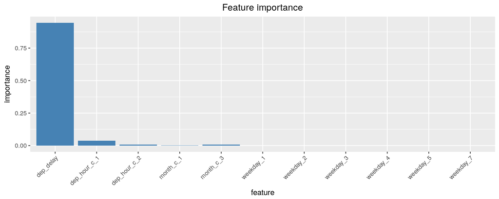

```r
# importance <- get_feat_importance(model))
ggplot(importance, aes(x=feature, y=importance)) +
  geom_bar(stat = 'identity', fill = 'steel blue') +
  ggtitle('Feature importance') +
  theme(plot.title = element_text(hjust = 0.5),
        axis.text.x = element_text(angle = 45, hjust = 1))
```

- *dep_delay* is dominant

```r
get_feat_importance <- function(model) {
  s <- summary(model)
  features <- s$features %>% unlist()
  imp_ext <- stringr::str_extract_all(s$featureImportances, '\\[(.*?)\\]') %>%
    unlist()
  importance <- imp_ext[length(imp_ext)] %>%
    stringr::str_replace_all('[\\[|\\]]', '') %>%
    strsplit(',') %>% unlist() %>% as.numeric()
  data.frame(feature = features, importance = importance) %>%
    dplyr::arrange(-importance) %>% as.tibble()
}
```

# Further topics

- Hive UDF
  - [Hive UDFs](https://cwiki.apache.org/confluence/display/Hive/LanguageManual+UDF) can be run alongside Spark SQL
  - [Spark should be built with Hive](http://jaehyeon-kim.github.io/2016/04/Boost-SparkR-with-Hive.html)
- [sparklyr](https://spark.rstudio.com/)
  - has a complete dplyr backend, [too tight integration?](http://spark.rstudio.com/#using-sql)
  - has more features for data analysis
    - [feature transformers](https://spark.rstudio.com/mlib/#transformers) vs [one-hot encoding and a few more](https://databricks.com/blog/2015/10/05/generalized-linear-models-in-sparkr-and-r-formula-support-in-mllib.html)
  - deprecated way of creating Spark session
    - not sure if SparkR and sparklyr can be used side by side
- Production environment
  - [Amazon EMR](https://aws.amazon.com/emr/)
    - managed Hadoop framework on AWS
    - [automatic scaling](https://docs.aws.amazon.com/emr/latest/ManagementGuide/emr-automatic-scaling.html)
    - [instance fleets](https://aws.amazon.com/blogs/aws/new-amazon-emr-instance-fleets/)
  - Other options
    - [amplab/spark-ec2](https://github.com/amplab/spark-ec2/) - no longer maintained
    - [Flintrock](https://github.com/nchammas/flintrock) - currently undergoing heavy development